# Semester Project: Final Paper

Max Samfield

### Introduction

Automobiles have played a significant role in American history; our culture, politics, economy, and infrastructure have all been influenced by the automobile industry. Because of this, many regard automobile ownership as a logistic necessity for living in the United States. However, especially in light of high traffic fatalities and the increasing popularity of ‘anti-car’ movements, many have begun to question whether or not automobiles truly improve the lives of people in the modern world. I believe the validity of this notion can be tested by assessing whether or not there is a relationship between American neighborhoods’ walkability and the percentage of zero-car households therein. If Americans willingly forego automobile ownership when walkable infrastructure is available, are automobiles truly beneficial, or just a manufactured need?

I would like to assess whether or not there is a relationship between American cities’ walkability and the percentage of zero-car households therein. I hypothesize that there is a positive relationship between the walkability of an area and the number of zero-car households therein.

### Data Description

This project uses two data sources.

The primary data source I refer to in this project is the EPA’s Smart Location Database (found at epa.gov), which is a geographic database containing an observation for every census block group in the United States with the purpose of “measuring location efficiency”. Each observation refers to a single census block group, with over 90 attributes ranging from geographic descriptors to economic, demographic, and infrastructure data. My two main variables of interest – [NatWalkInd] and [Pct_AO0] – come from this dataset. [NatWalkInd] refers to the National Walkability Index, which uses a continuous 20-point scale to assign a “walkability score” to each census block group in the Smart Location Database. This score is calculated using a formula that quantifies and sums four relevant characteristics of the census block group being scored: - Intersection density score, which is calculated by assessing the number of intersections in a given area, wherein intersections that promote street connectivity and are pedestrian friendly are given higher weight, and heavily auto-oriented intersections are given zero weights. - Transit stop proximity score, which is calculated using the distance from the CBG’s population-weighted centroid to the nearest transit stop. Shorter distances to the nearest transit stop yield a higher score. - Employment mix score, which is based on the mixture of employment types in the census block group. A large variety of employment types yields a higher score. - Employment and household mix score, which is based on the mixture of employment types and occupied housing. A census block group with a diverse set of employment types as well as a large quantity of occupied housing units will have a relatively high score. More details on how the National Walkability Index is calculated can be found in its corresponding Methodology and User Guide, which is found on the EPA’s website.

My second variable of interest, [Pct_AO0], refers to the percentage of zero-car households in each census block group. Estimated using household unit counts and American Community Survey data, this estimated percentage is represented by a value between 0 and 1.

As my second data source, I refer to official 2019 census data on Median Household Income per census block group. I merged this dataset (found at data.census.gov) with the Smart Location Database such that every census block group observation now has median income (in 2019 inflation adjusted-dollars) included alongside all of the Smart Location Database’s other attributes. This is done so that I can control for median household income when gauging the effect of walkability on automobile ownership.

Finally, I split this merged dataset into three smaller datasets, which respectively contain the census block group observations for Cook County, Illinois; Duval County, Florida; and Travis County, Texas. I did this for the purpose of separately testing my hypothesis in the three major metropolitan areas contained by these counties – Chicago, Jacksonville, and Austin. I recoded these three county datasets to remove all missing and null values from the automobile ownership, walkability score, and median income variables. Additionally, I recode [Pct_AO0] to be more numerically standard (0.50 -> 50.0) and rename it as [ZeroCar].

```r
library(htmltools)
htmltools::includeHTML("ChicagoMergeForEmail.html")
```

```python
import pandas as pd
import numpy as np
import matplotlib.pyplot as plt

# Enable inline mode for matplotlib so that Jupyter displays graphs
%matplotlib inline
```

```python
# Smart Location Database for Cook County
dfChicagoWalk = pd.read_csv('Chicago.csv')
dfChicagoWalk
```

|  | Unnamed: 0 | OBJECTID | GEOID10 | GEOID20 | STATEFP | COUNTYFP | TRACTCE | BLKGRPCE | CSA | CSA_Name | ... | D5DRI | D5DE | D5DEI | D2A_Ranked | D2B_Ranked | D3B_Ranked | D4A_Ranked | NatWalkInd | Shape_Length | Shape_Area |
| --- | --- | --- | --- | --- | --- | --- | --- | --- | --- | --- | --- | --- | --- | --- | --- | --- | --- | --- | --- | --- | --- |
| 0 | 80610 | 80611 | 1.700000e+11 | 1.700000e+11 | 17 | 31 | 813400 | 1 | 176.0 | Chicago-Naperville, IL-IN-WI | ... | 0.321511 | 0.000341 | 0.439577 | 10 | 4 | 15 | 18 | 13.333333 | 3228.808659 | 415954.4214 |
| 1 | 80631 | 80632 | 1.700000e+11 | 1.700000e+11 | 17 | 31 | 820502 | 2 | 176.0 | Chicago-Naperville, IL-IN-WI | ... | 0.015313 | 0.000036 | 0.045934 | 10 | 11 | 16 | 16 | 14.166667 | 3246.015216 | 455768.8439 |
| 2 | 80632 | 80633 | 1.700000e+11 | 1.700000e+11 | 17 | 31 | 672000 | 3 | 176.0 | Chicago-Naperville, IL-IN-WI | ... | 0.200935 | 0.000276 | 0.354852 | 1 | 8 | 17 | 20 | 13.833333 | 1832.236126 | 184726.5606 |
| 3 | 80633 | 80634 | 1.700000e+11 | 1.700000e+11 | 17 | 31 | 560800 | 3 | 176.0 | Chicago-Naperville, IL-IN-WI | ... | 0.151207 | 0.000157 | 0.202392 | 11 | 17 | 19 | 17 | 16.666667 | 2263.776292 | 232894.0231 |
| 4 | 80707 | 80708 | 1.700000e+11 | 1.700000e+11 | 17 | 31 | 819600 | 3 | 176.0 | Chicago-Naperville, IL-IN-WI | ... | 0.017831 | 0.000036 | 0.046363 | 13 | 18 | 19 | 20 | 18.166667 | 3253.385089 | 496982.8765 |
| ... | ... | ... | ... | ... | ... | ... | ... | ... | ... | ... | ... | ... | ... | ... | ... | ... | ... | ... | ... | ... | ... |
| 3988 | 90292 | 90293 | 1.700000e+11 | 1.700000e+11 | 17 | 31 | 310200 | 1 | 176.0 | Chicago-Naperville, IL-IN-WI | ... | 0.521675 | 0.000510 | 0.656375 | 14 | 12 | 18 | 17 | 16.000000 | 2149.187383 | 193744.1179 |
| 3989 | 90293 | 90294 | 1.700000e+11 | 1.700000e+11 | 17 | 31 | 310200 | 2 | 176.0 | Chicago-Naperville, IL-IN-WI | ... | 0.520929 | 0.000488 | 0.627768 | 14 | 18 | 20 | 20 | 18.666667 | 1910.402491 | 126828.0528 |
| 3990 | 90294 | 90295 | 1.700000e+11 | 1.700000e+11 | 17 | 31 | 400500 | 2 | 176.0 | Chicago-Naperville, IL-IN-WI | ... | 0.370280 | 0.000355 | 0.457431 | 1 | 1 | 16 | 18 | 11.666667 | 1618.707577 | 136542.3594 |
| 3991 | 90295 | 90296 | 1.700000e+11 | 1.700000e+11 | 17 | 31 | 480400 | 6 | 176.0 | Chicago-Naperville, IL-IN-WI | ... | 0.450371 | 0.000323 | 0.415650 | 2 | 1 | 11 | 17 | 9.833333 | 2655.787299 | 229016.3083 |
| 3992 | 90296 | 90297 | 1.700000e+11 | 1.700000e+11 | 17 | 31 | 480400 | 7 | 176.0 | Chicago-Naperville, IL-IN-WI | ... | 0.450570 | 0.000323 | 0.415626 | 8 | 1 | 18 | 17 | 13.166667 | 2663.548274 | 232474.8874 |

3993 rows × 118 columns

```python
# Median Household Income 2019 for Cook County
dfChicagoIncome = pd.read_csv('CookCGMedianIncome19.csv')
dfChicagoIncome

# And they match! 3993 entries for block groups
```

|  | Label (Grouping) | Median household income in the past 12 months (in 2019 inflation-adjusted dollars) |
| --- | --- | --- |
| 0 | Block Group 1, Census Tract 101, Cook County, ... | NaN |
| 1 | Estimate | - |
| 2 | Margin of Error | ** |
| 3 | Block Group 2, Census Tract 101, Cook County, ... | NaN |
| 4 | Estimate | 21,827 |
| ... | ... | ... |
| 11974 | Estimate | - |
| 11975 | Margin of Error | ** |
| 11976 | Block Group 0, Census Tract 9900, Cook County,... | NaN |
| 11977 | Estimate | - |
| 11978 | Margin of Error | ** |

11979 rows × 2 columns

```python
# Remove Margin of Error rows from above

dfChicagoIncomeDropped = dfChicagoIncome.drop(dfChicagoIncome.index[range(2,len(dfChicagoIncome),3)])
```

```python
# Just renaming the median income column
dfChicagoIncomeDropped.rename(columns={'Median household income in the past 12 months (in 2019 inflation-adjusted dollars)': 'MedianIncome'}, inplace=True)
```

```python
# Shifting all values from second column up, so they lie in same row as Block Group identifiers
dfChicagoIncomeDropped['MedianIncome'] = dfChicagoIncomeDropped['MedianIncome'].shift(-1)
```

```python
# resetting index so we can more easily drop now-empty rows
dfChicagoIncomeNew = dfChicagoIncomeDropped.reset_index()
```

```python
# getting rid of old 'index' column that was moved over
dfChicagoIncomeNew = dfChicagoIncomeNew.drop('index', axis=1)
```

```python
# dropping every 2nd row, which we no longer need
dfChicagoIncomeNew2 = dfChicagoIncomeNew.loc[dfChicagoIncomeNew.index % 2 == 0]
```

```python
# once again resetting index
dfChicagoIncomeNew2 = dfChicagoIncomeNew2.reset_index()
dfChicagoIncomeNew2 = dfChicagoIncomeNew2.drop('index', axis=1)
```

```python
# sorting the Smart Location Database so that it lines up with our median income data
dfChicagoWalkTractAsc = dfChicagoWalk.sort_values(['TRACTCE', 'BLKGRPCE'], ascending = [True, True])
```

```python
# Resetting the index on the ascending Smart Location Database for Chicago ...
# ... so that indexes match up when I merge in the median income data
dfChicagoWalkTractAsc = dfChicagoWalkTractAsc.reset_index()
dfChicagoWalkTractAsc = dfChicagoWalkTractAsc.drop('index', axis=1)

dfChicagoWalkTractAsc['MedianIncome'] = dfChicagoIncomeNew2['MedianIncome']
dfChicagoWalkTractAsc
```

|  | Unnamed: 0 | OBJECTID | GEOID10 | GEOID20 | STATEFP | COUNTYFP | TRACTCE | BLKGRPCE | CSA | CSA_Name | ... | D5DE | D5DEI | D2A_Ranked | D2B_Ranked | D3B_Ranked | D4A_Ranked | NatWalkInd | Shape_Length | Shape_Area | MedianIncome |
| --- | --- | --- | --- | --- | --- | --- | --- | --- | --- | --- | --- | --- | --- | --- | --- | --- | --- | --- | --- | --- | --- |
| 0 | 89316 | 89317 | 1.700000e+11 | 1.700000e+11 | 17 | 31 | 10100 | 1 | 176.0 | Chicago-Naperville, IL-IN-WI | ... | 0.000352 | 0.452527 | 1 | 4 | 15 | 16 | 11.166667 | 1251.798027 | 6.246259e+04 | - |
| 1 | 88764 | 88765 | 1.700000e+11 | 1.700000e+11 | 17 | 31 | 10100 | 2 | 176.0 | Chicago-Naperville, IL-IN-WI | ... | 0.000408 | 0.525678 | 6 | 3 | 19 | 17 | 13.500000 | 1971.808254 | 1.833152e+05 | 21,827 |
| 2 | 82211 | 82212 | 1.700000e+11 | 1.700000e+11 | 17 | 31 | 10100 | 3 | 176.0 | Chicago-Naperville, IL-IN-WI | ... | 0.000350 | 0.449998 | 4 | 3 | 19 | 19 | 13.833333 | 2927.115469 | 1.339733e+05 | 54,297 |
| 3 | 88940 | 88941 | 1.700000e+11 | 1.700000e+11 | 17 | 31 | 10201 | 1 | 176.0 | Chicago-Naperville, IL-IN-WI | ... | 0.000374 | 0.482074 | 2 | 7 | 19 | 19 | 14.166667 | 1327.654856 | 9.592139e+04 | 42,778 |
| 4 | 82216 | 82217 | 1.700000e+11 | 1.700000e+11 | 17 | 31 | 10201 | 2 | 176.0 | Chicago-Naperville, IL-IN-WI | ... | 0.000369 | 0.474560 | 2 | 18 | 20 | 17 | 15.666667 | 2692.093356 | 2.593246e+05 | 39,535 |
| ... | ... | ... | ... | ... | ... | ... | ... | ... | ... | ... | ... | ... | ... | ... | ... | ... | ... | ... | ... | ... | ... |
| 3988 | 86452 | 86453 | 1.700000e+11 | 1.700000e+11 | 17 | 31 | 843900 | 4 | 176.0 | Chicago-Naperville, IL-IN-WI | ... | 0.000468 | 0.603048 | 1 | 1 | 1 | 18 | 6.666667 | 948.156277 | 5.507922e+04 | - |
| 3989 | 84915 | 84916 | 1.700000e+11 | 1.700000e+11 | 17 | 31 | 843900 | 5 | 176.0 | Chicago-Naperville, IL-IN-WI | ... | 0.000468 | 0.602718 | 1 | 4 | 9 | 20 | 10.500000 | 947.565149 | 5.503219e+04 | 53,785 |
| 3990 | 84917 | 84918 | 1.700000e+11 | 1.700000e+11 | 17 | 31 | 980000 | 1 | 176.0 | Chicago-Naperville, IL-IN-WI | ... | 0.000181 | 0.233404 | 8 | 5 | 6 | 15 | 9.166667 | 21465.112990 | 1.998202e+07 | - |
| 3991 | 86351 | 86352 | 1.700000e+11 | 1.700000e+11 | 17 | 31 | 980100 | 1 | 176.0 | Chicago-Naperville, IL-IN-WI | ... | -99999.000000 | -99999.000000 | 5 | 3 | 11 | 1 | 5.333333 | 7212.847361 | 2.981782e+06 | - |
| 3992 | 81783 | 81784 | 1.700000e+11 | 1.700000e+11 | 17 | 31 | 990000 | 0 | 176.0 | Chicago-Naperville, IL-IN-WI | ... | -99999.000000 | -99999.000000 | 1 | 1 | 1 | 1 | 1.000000 | 176696.467100 | 1.717070e+09 | - |

3993 rows × 119 columns

```python
#dfChicagoMerged_csv = dfChicagoWalkTractAsc.to_csv('ChicagoMerged.csv', index=True)
#print('\nCSV String:\n', dfChicagoMerged_csv)
```

[output not shown]

Above, I’ve presented the Python code I used to create the Cook County dataset. This code is identical to the code used to create the same datasets for Duval and Travis County.

```r
AustinMerged <- read.csv("AustinMerged.csv")
JacksonvilleMerged <- read.csv("JacksonvilleMerged.csv")
ChicagoMerged <- read.csv("ChicagoMerged.csv")
```

### Descriptive Analyses

As stated, walkability index scores take a value on a continuous scale with values ranging from 1 to 20, with higher values indicating a census block group that is more friendly to pedestrians in regards to both infrastructure and services. The EPA describes four ranges by which scores can be qualitatively assessed: - 1 - 5.75 indicates “Least Walkable” areas - 5.76 - 10.5 indicates “Below average walkable” areas - 10.51 - 15.25 indicates “Above average walkable” areas - 15.26 - 20 indicates “Most walkable” areas

Percentage of zero-car households [Pct_AO0] is represented by a value between 0 and 1. For example, if 40% of households in a census block group own zero automobiles, this variable’s value for that observation would be 0.4.

```r
combined <- rbind(AustinMerged, JacksonvilleMerged, ChicagoMerged)
mean(combined$NatWalkInd)
```

```
## [1] 13.17727
```

```r
mean(AustinMerged$NatWalkInd)
```

```
## [1] 11.51638
```

```r
mean(JacksonvilleMerged$NatWalkInd)
```

```
## [1] 11.40884
```

```r
mean(ChicagoMerged$NatWalkInd)
```

```
## [1] 13.63553
```

```r
mean(AustinMerged$Pct_AO0)
```

```
## [1] 0.05918747
```

```r
mean(JacksonvilleMerged$Pct_AO0)
```

```
## [1] 0.103137
```

```r
mean(ChicagoMerged$Pct_AO0)
```

```
## [1] 0.1690219
```

Above, we see the means of [Pct_AO0] in each county. Surprisingly, Duval County has, on average, nearly twice the number of zero-car households per census block group than Travis County. Unsurprisingly, Cook County’s mean is significantly higher than both Duval and Travis County.

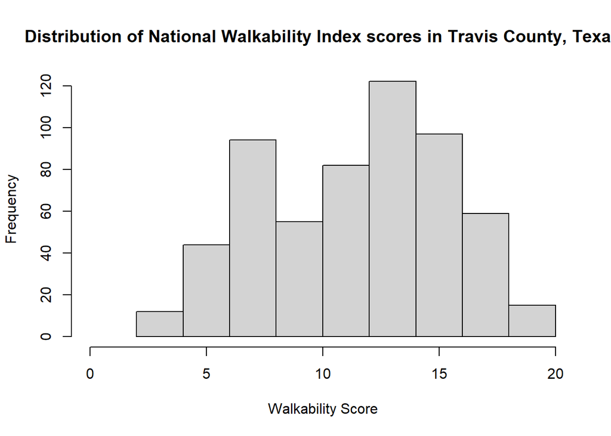

```r
hist(AustinMerged$NatWalkInd, main="Distribution of National Walkability Index scores in Travis County, Texas", xlab="Walkability Score", xlim=c(0, 20))
```

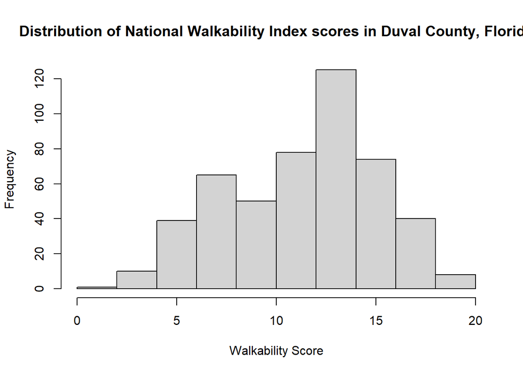

```r
hist(JacksonvilleMerged$NatWalkInd, main="Distribution of National Walkability Index scores in Duval County, Florida", xlab="Walkability Score")
```

In regards to National Walkability Index scores, Duval and Travis County have similar, fairly left-skewed distributions.

These two distributions do still have a noticeable difference. Travis County seems to have more variance in the observations that make up its distribution, largely due to a spike in observations with an approximate score of 7, which is much more prominent than an identically-placed spike in Duval County’s distribution. Given the near-identical means in walkability score between these two locations, it seems that, while a larger proportion of Travis County residents live in “Below Average Walkable” neighborhoods than Duval County residents, it’s also the case that a larger proportion of Travis County residents live in “Most Walkable” neighborhoods than Duval County residents as well.

Despite this difference, these two locations still have fairly similar distributions. With an average around 11.5, both distributions have a similar peak sitting around 13. In each, values after the distribution’s peak drop steadily and steeply, with a fairly high number of observations around a score of 15, and very few observations (less than 20) between a score of 18 and 20. Likewise, each has very few census block groups with walkability scores as low as, or less than, 5. As such, both counties appear to be similar in that a typical resident is likely to reside in a neighborhood deemed slightly below or slighty above average in its walkability, with very few residents found above or below those ranges. Ultimately, the one difference of note is simply that, in Travis County, there is more disparity in neighborhood walkability.

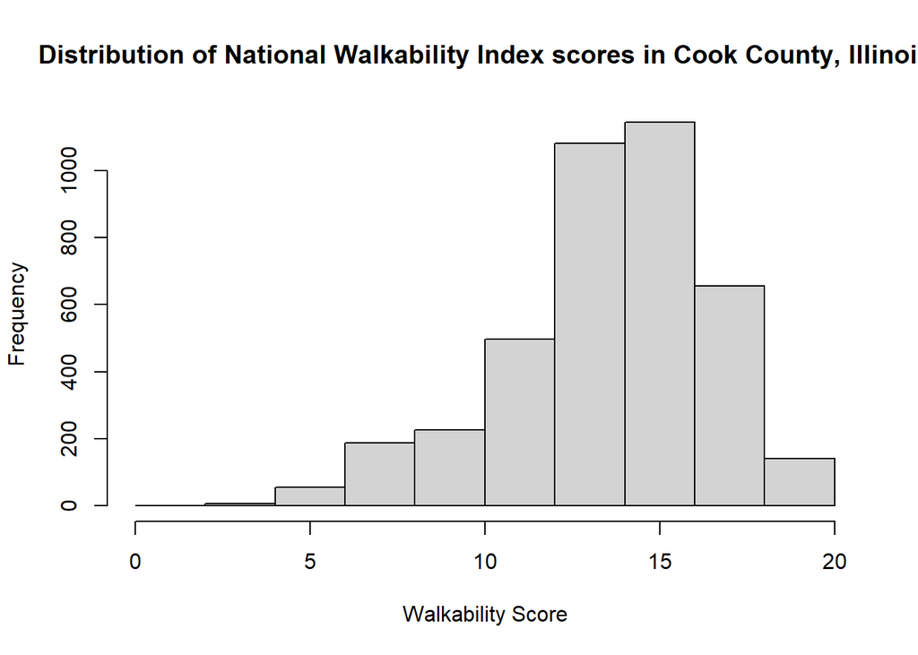

```r
hist(ChicagoMerged$NatWalkInd, main="Distribution of National Walkability Index scores in Cook County, Illinois", xlab="Walkability Score")
```

The distribution of walkability scores for Cook County is markedly different from those of Duval and Travis County. While it also left-skewed, its values have a significantly higher concentration around its slightly higher mean. Compared to Duval County and Travis County, a much greater proportion of Cook County’s residents live in walkable areas. For example, the number of Chicago residents living in “Below Average Walkable” areas is less than half of the same value for both Duval and Travis County, and the number of residents living in areas deemed “Most Walkable” is double that of Duval County. Likewise, as little as 1% of Chicago’s population lives in “Least Walkable” areas. This low variance and slightly higher mean are likely explained by the prevalence of high-density housing in Chicago, which is also enabled by a robust rail transit system within Chicago.

```r
# In Travis County, what percentage of walkability scores are in each range?
sum(AustinMerged$NatWalkInd >= 1 & AustinMerged$NatWalkInd <= 5.75) / 580
```

```
## [1] 0.07758621
```

```r
sum(AustinMerged$NatWalkInd >= 5.76 & AustinMerged$NatWalkInd <= 10.5) / 580
```

```
## [1] 0.3051724
```

```r
sum(AustinMerged$NatWalkInd >= 10.51 & AustinMerged$NatWalkInd <= 15.25) / 580
```

```
## [1] 0.4310345
```

```r
sum(AustinMerged$NatWalkInd >= 15.26 & AustinMerged$NatWalkInd <= 20) / 580
```

```
## [1] 0.1862069
```

```r
# In Duval County, what percentage of walkability scores are in each range?
sum(JacksonvilleMerged$NatWalkInd >= 1 & JacksonvilleMerged$NatWalkInd <= 5.75) / 490
```

```
## [1] 0.0877551
```

```r
sum(JacksonvilleMerged$NatWalkInd >= 5.76 & JacksonvilleMerged$NatWalkInd <= 10.5) / 490
```

```
## [1] 0.2816327
```

```r
sum(JacksonvilleMerged$NatWalkInd >= 10.51 & JacksonvilleMerged$NatWalkInd <= 15.25) / 490
```

```
## [1] 0.4918367
```

```r
sum(JacksonvilleMerged$NatWalkInd >= 15.26 & JacksonvilleMerged$NatWalkInd <= 20) / 490
```

```
## [1] 0.1387755
```

```r
# In Cook County, what percentage of walkability scores are in each range?
sum(ChicagoMerged$NatWalkInd >= 1 & ChicagoMerged$NatWalkInd <= 5.75) / 3993
```

```
## [1] 0.01101928
```

```r
sum(ChicagoMerged$NatWalkInd >= 5.76 & ChicagoMerged$NatWalkInd <= 10.5) / 3993
```

```
## [1] 0.1289757
```

```r
sum(ChicagoMerged$NatWalkInd >= 10.51 & ChicagoMerged$NatWalkInd <= 15.25) / 3993
```

```
## [1] 0.5562234
```

```r
sum(ChicagoMerged$NatWalkInd >= 15.26 & ChicagoMerged$NatWalkInd <= 20) / 3993
```

```
## [1] 0.3037816
```

Above, the percentage of census block groups found in each of the EPA’s walkability categories (Least Walkable, Below Average Walkable, Above Average Walkable, and Most Walkable) are presented for Travis, Duval, and Cook County respectively. These values clearly reflect the attributes of the distributions for walkability scores above.

```r
AustinMerged$MedianIncome <- gsub(",", "", AustinMerged$MedianIncome)
AustinMerged$MedianIncome <- as.numeric(AustinMerged$MedianIncome)
JacksonvilleMerged$MedianIncome <- gsub(",", "", JacksonvilleMerged$MedianIncome)
JacksonvilleMerged$MedianIncome <- as.numeric(JacksonvilleMerged$MedianIncome)
# 33, 19 ... 28, 27
```

```r
ChicagoMerged$MedianIncome <- gsub(",", "", ChicagoMerged$MedianIncome)
ChicagoMerged$MedianIncome <- as.numeric(ChicagoMerged$MedianIncome)
```

Above, I convert Median Income strings (which included commas) to integers.

```r
# Now to get rid of empty, negative, and null values in each dataset
# Just for median income since we checked the other variables in data writeup
AustinMerged <- AustinMerged[!(is.na(AustinMerged$MedianIncome) | AustinMerged$MedianIncome=="" | AustinMerged$MedianIncome<0), ]
```

```r
JacksonvilleMerged <- JacksonvilleMerged[!(is.na(JacksonvilleMerged$MedianIncome) | JacksonvilleMerged$MedianIncome=="" | JacksonvilleMerged$MedianIncome<0), ]
```

```r
ChicagoMerged <- ChicagoMerged[!(is.na(ChicagoMerged$MedianIncome) | ChicagoMerged$MedianIncome=="" | ChicagoMerged$MedianIncome<0), ]
```

Above, I clear all rows with negative, null, or empty values in the Median Income column. (The same was done for my explanatory and response variables in the data writeup.)

```r
AustinMerged$ZeroCar <- AustinMerged$Pct_AO0 * 100
```

```r
JacksonvilleMerged$ZeroCar <- JacksonvilleMerged$Pct_AO0 * 100
```

```r
ChicagoMerged$ZeroCar <- ChicagoMerged$Pct_AO0 * 100
```

Above, I create a new variable [ZeroCar], which converts [Pct_AO0] to standard percentages. (0.55 is converted to 55.0)

### Main Analyses

Here, I estimate the relationship between area’s walkability and the percentage of zero-car households by performing a regression on each county’s dataset. By performing the same regression on each of these 3 counties, I will be able to see whether or not differences in county-wide infrastructure trends affect the relationship between my variables of interest. For example, because Austin, which dominates Travis County, lacks a robust passenger rail system like Chicago, it may be the case that Travis County households are more likely to own an automobile even when living in a walkable census block group; such a hypothetical could potentially weaken the relationship I am testing for in one county, but not in another.

```r
AustinMidInc <- AustinMerged[(AustinMerged$MedianIncome >= 45000) & (AustinMerged$MedianIncome <= 120000), ]

AustinMid.reg <- lm(AustinMidInc$ZeroCar ~ AustinMidInc$NatWalkInd)
summary(AustinMid.reg)
```

```
##
## Call:
## lm(formula = AustinMidInc$ZeroCar ~ AustinMidInc$NatWalkInd)
##
## Residuals:
##    Min     1Q Median     3Q    Max
## -7.225 -3.135 -1.235  1.678 27.799
##
## Coefficients:
##                         Estimate Std. Error t value Pr(>|t|)
## (Intercept)             -0.42565    0.77803  -0.547    0.585
## AustinMidInc$NatWalkInd  0.45452    0.06339   7.170 3.83e-12 ***
## ---
## Signif. codes:  0 '***' 0.001 '**' 0.01 '*' 0.05 '.' 0.1 ' ' 1
##
## Residual standard error: 4.974 on 387 degrees of freedom
## Multiple R-squared:  0.1173, Adjusted R-squared:  0.115
## F-statistic: 51.41 on 1 and 387 DF,  p-value: 3.826e-12
```

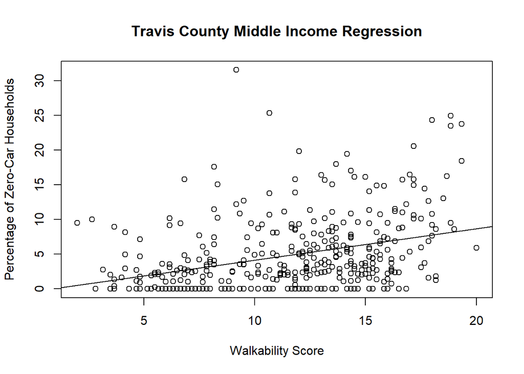

```r
plot(AustinMidInc$ZeroCar ~ AustinMidInc$NatWalkInd, main="Travis County Middle Income Regression", xlab="Walkability Score", ylab="Percentage of Zero-Car Households")
abline(AustinMid.reg)
```

```r
AustinLowInc <- AustinMerged[(AustinMerged$MedianIncome >= 4000) & (AustinMerged$MedianIncome <= 60000), ]

AustinLow.reg <- lm(AustinLowInc$ZeroCar ~ AustinLowInc$NatWalkInd)
summary(AustinLow.reg)
```

```
##
## Call:
## lm(formula = AustinLowInc$ZeroCar ~ AustinLowInc$NatWalkInd)
##
## Residuals:
##     Min      1Q  Median      3Q     Max
## -13.290  -5.861  -1.737   3.533  34.495
##
## Coefficients:
##                         Estimate Std. Error t value Pr(>|t|)
## (Intercept)              -1.2724     2.6043  -0.489    0.626
## AustinLowInc$NatWalkInd   0.9197     0.1972   4.665 6.38e-06 ***
## ---
## Signif. codes:  0 '***' 0.001 '**' 0.01 '*' 0.05 '.' 0.1 ' ' 1
##
## Residual standard error: 8.265 on 164 degrees of freedom
## Multiple R-squared:  0.1171, Adjusted R-squared:  0.1117
## F-statistic: 21.76 on 1 and 164 DF,  p-value: 6.383e-06
```

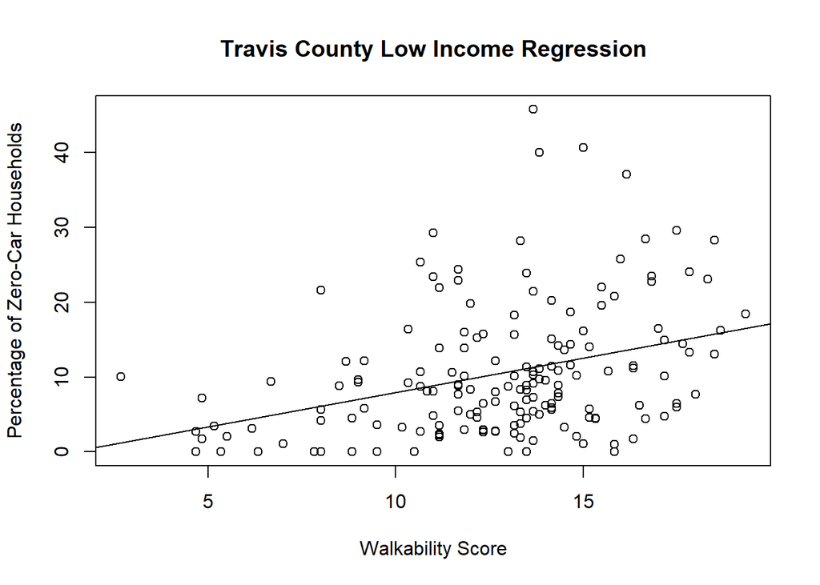

```r
plot(AustinLowInc$ZeroCar ~ AustinLowInc$NatWalkInd, main="Travis County Low Income Regression", xlab="Walkability Score", ylab="Percentage of Zero-Car Households")
abline(AustinLow.reg)
```

```r
AustinHighInc <- AustinMerged[(AustinMerged$MedianIncome >= 150000), ]

AustinHigh.reg <- lm(AustinHighInc$ZeroCar ~ AustinHighInc$NatWalkInd)
summary(AustinHigh.reg)
```

```
##
## Call:
## lm(formula = AustinHighInc$ZeroCar ~ AustinHighInc$NatWalkInd)
##
## Residuals:
##     Min      1Q  Median      3Q     Max
## -3.5427 -1.3069 -0.7567  0.3154 19.2586
##
## Coefficients:
##                          Estimate Std. Error t value Pr(>|t|)
## (Intercept)               -0.8587     1.5046  -0.571   0.5708
## AustinHighInc$NatWalkInd   0.2809     0.1528   1.839   0.0719 .
## ---
## Signif. codes:  0 '***' 0.001 '**' 0.01 '*' 0.05 '.' 0.1 ' ' 1
##
## Residual standard error: 3.558 on 50 degrees of freedom
## Multiple R-squared:  0.06335,    Adjusted R-squared:  0.04462
## F-statistic: 3.382 on 1 and 50 DF,  p-value: 0.07186
```

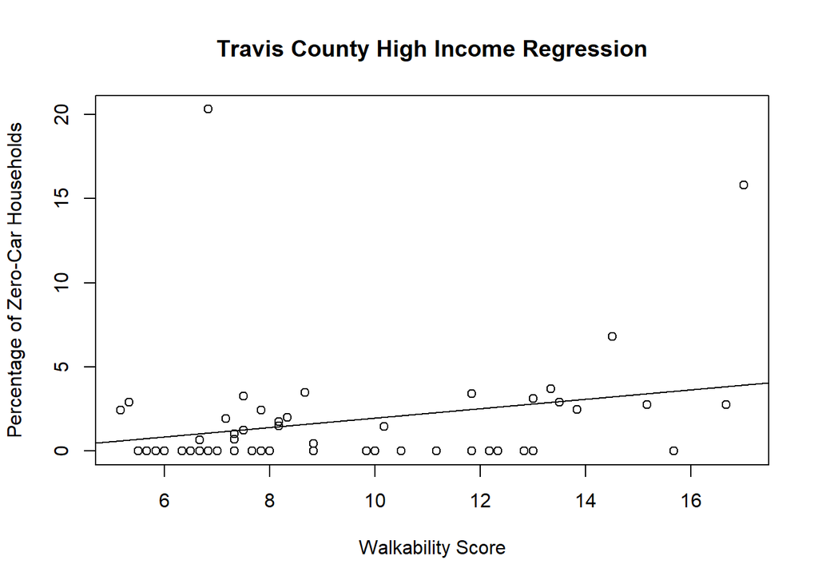

```r
plot(AustinHighInc$ZeroCar ~ AustinHighInc$NatWalkInd, main="Travis County High Income Regression", xlab="Walkability Score", ylab="Percentage of Zero-Car Households")
abline(AustinHigh.reg)
```

```r
JacksonvilleMidInc <- JacksonvilleMerged[(JacksonvilleMerged$MedianIncome >= 45000) & (JacksonvilleMerged$MedianIncome <= 120000), ]

JacksonvilleMid.reg <- lm(JacksonvilleMidInc$ZeroCar ~ JacksonvilleMidInc$NatWalkInd)
summary(JacksonvilleMid.reg)
```

```
##
## Call:
## lm(formula = JacksonvilleMidInc$ZeroCar ~ JacksonvilleMidInc$NatWalkInd)
##
## Residuals:
##    Min     1Q Median     3Q    Max
## -7.418 -3.966 -1.378  1.845 63.239
##
## Coefficients:
##                               Estimate Std. Error t value Pr(>|t|)
## (Intercept)                     2.4963     1.1234   2.222  0.02705 *
## JacksonvilleMidInc$NatWalkInd   0.2660     0.1018   2.614  0.00943 **
## ---
## Signif. codes:  0 '***' 0.001 '**' 0.01 '*' 0.05 '.' 0.1 ' ' 1
##
## Residual standard error: 6.568 on 287 degrees of freedom
## Multiple R-squared:  0.02325,    Adjusted R-squared:  0.01984
## F-statistic: 6.831 on 1 and 287 DF,  p-value: 0.009432
```

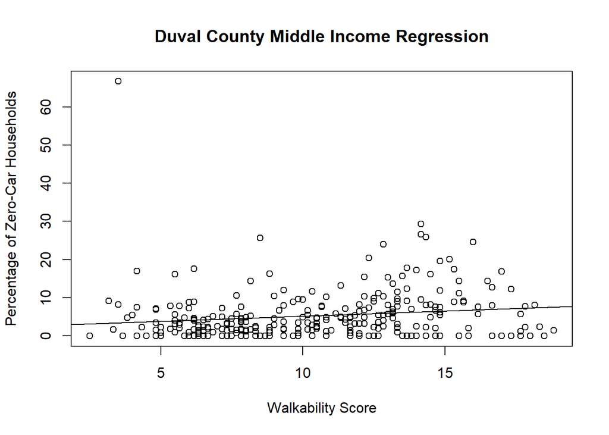

```r
plot(JacksonvilleMidInc$ZeroCar ~ JacksonvilleMidInc$NatWalkInd, main="Duval County Middle Income Regression", xlab="Walkability Score", ylab="Percentage of Zero-Car Households")
abline(JacksonvilleMid.reg)
```

```r
JacksonvilleLowInc <- JacksonvilleMerged[(JacksonvilleMerged$MedianIncome >= 4000) & (JacksonvilleMerged$MedianIncome <= 60000), ]

JacksonvilleLow.reg <- lm(JacksonvilleLowInc$ZeroCar ~ JacksonvilleLowInc$NatWalkInd)
summary(JacksonvilleLow.reg)
```

```
##
## Call:
## lm(formula = JacksonvilleLowInc$ZeroCar ~ JacksonvilleLowInc$NatWalkInd)
##
## Residuals:
##     Min      1Q  Median      3Q     Max
## -17.793  -8.802  -3.268   5.706  64.142
##
## Coefficients:
##                               Estimate Std. Error t value Pr(>|t|)
## (Intercept)                    -2.1883     2.9558  -0.740     0.46
## JacksonvilleLowInc$NatWalkInd   1.3465     0.2329   5.781 1.89e-08 ***
## ---
## Signif. codes:  0 '***' 0.001 '**' 0.01 '*' 0.05 '.' 0.1 ' ' 1
##
## Residual standard error: 12.91 on 295 degrees of freedom
## Multiple R-squared:  0.1017, Adjusted R-squared:  0.0987
## F-statistic: 33.42 on 1 and 295 DF,  p-value: 1.892e-08
```

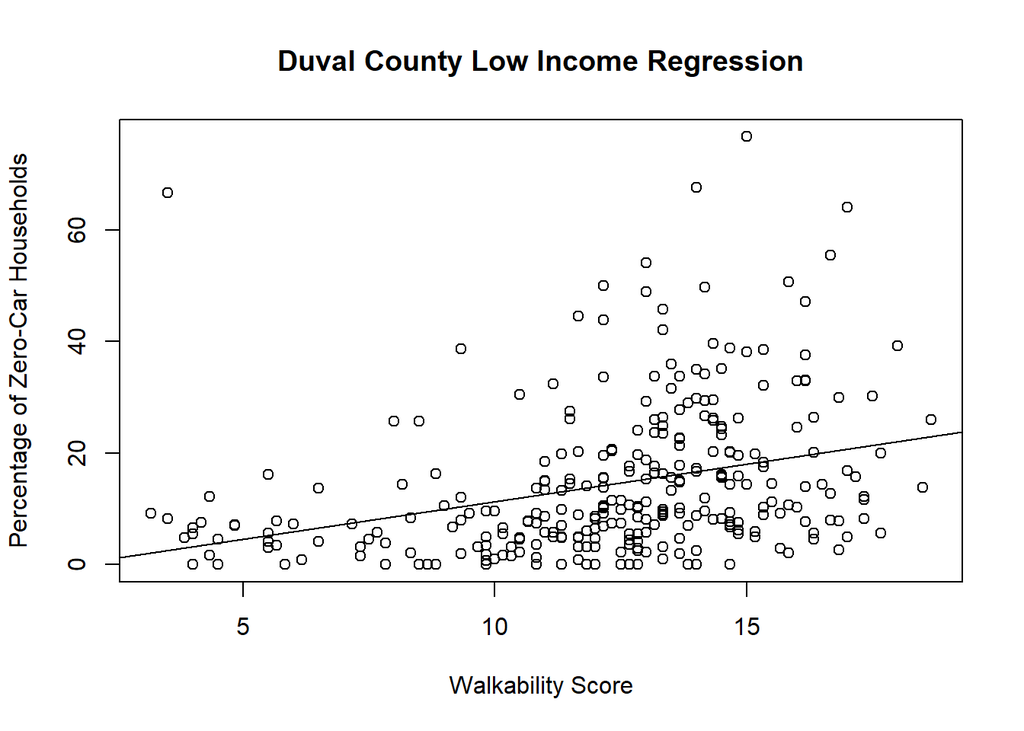

```r
plot(JacksonvilleLowInc$ZeroCar ~ JacksonvilleLowInc$NatWalkInd, main="Duval County Low Income Regression", xlab="Walkability Score", ylab="Percentage of Zero-Car Households")
abline(JacksonvilleLow.reg)
```

```r
JacksonvilleHighInc <- JacksonvilleMerged[(JacksonvilleMerged$MedianIncome >= 150000), ]

JacksonvilleHigh.reg <- lm(JacksonvilleHighInc$ZeroCar ~ JacksonvilleHighInc$NatWalkInd)
summary(JacksonvilleHigh.reg)
```

```
##
## Call:
## lm(formula = JacksonvilleHighInc$ZeroCar ~ JacksonvilleHighInc$NatWalkInd)
##
## Residuals:
##      1      2      3      4      5
## -3.602 -4.418 -1.431 -2.126 11.577
##
## Coefficients:
##                                Estimate Std. Error t value Pr(>|t|)
## (Intercept)                      0.5730    12.7610   0.045    0.967
## JacksonvilleHighInc$NatWalkInd   0.2330     0.9202   0.253    0.816
##
## Residual standard error: 7.596 on 3 degrees of freedom
## Multiple R-squared:  0.02093,    Adjusted R-squared:  -0.3054
## F-statistic: 0.06412 on 1 and 3 DF,  p-value: 0.8165
```

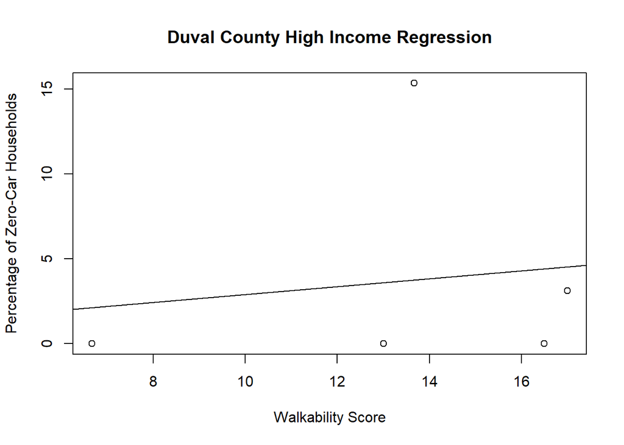

```r
plot(JacksonvilleHighInc$ZeroCar ~ JacksonvilleHighInc$NatWalkInd, main="Duval County High Income Regression", xlab="Walkability Score", ylab="Percentage of Zero-Car Households")
abline(JacksonvilleHigh.reg)
```

```r
ChicagoMidInc <- ChicagoMerged[(ChicagoMerged$MedianIncome >= 45000) & (ChicagoMerged$MedianIncome <= 120000), ]

ChicagoMid.reg <- lm(ChicagoMidInc$ZeroCar ~ ChicagoMidInc$NatWalkInd)
summary(ChicagoMid.reg)
```

```
##
## Call:
## lm(formula = ChicagoMidInc$ZeroCar ~ ChicagoMidInc$NatWalkInd)
##
## Residuals:
##     Min      1Q  Median      3Q     Max
## -18.489  -8.551  -3.390   4.764  66.128
##
## Coefficients:
##                          Estimate Std. Error t value Pr(>|t|)
## (Intercept)              -0.99304    1.19622   -0.83    0.407
## ChicagoMidInc$NatWalkInd  0.99060    0.08563   11.57   <2e-16 ***
## ---
## Signif. codes:  0 '***' 0.001 '**' 0.01 '*' 0.05 '.' 0.1 ' ' 1
##
## Residual standard error: 12.61 on 2373 degrees of freedom
## Multiple R-squared:  0.05338,    Adjusted R-squared:  0.05298
## F-statistic: 133.8 on 1 and 2373 DF,  p-value: < 2.2e-16
```

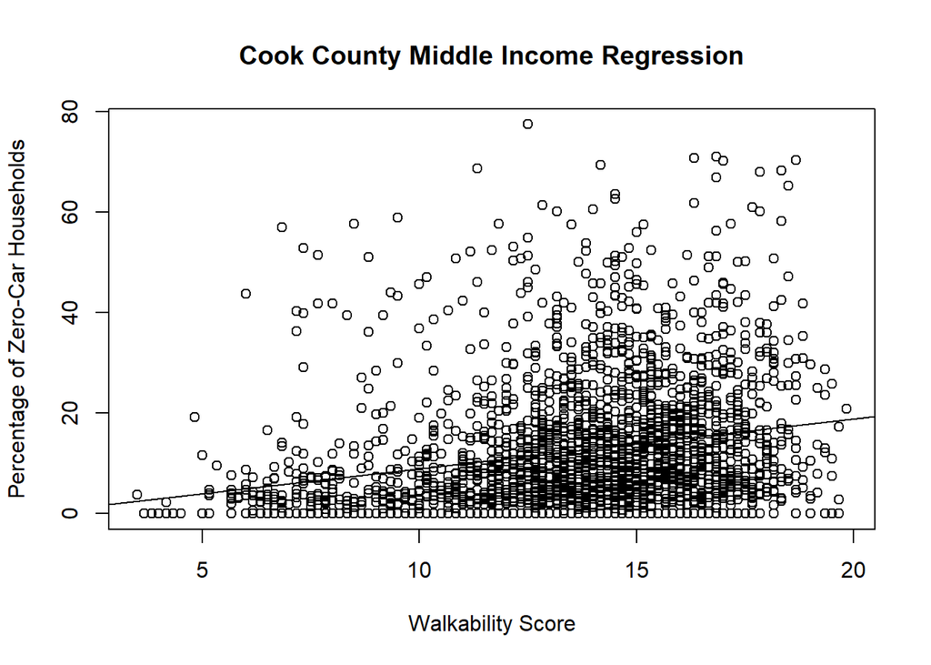

```r
plot(ChicagoMidInc$ZeroCar ~ ChicagoMidInc$NatWalkInd, main="Cook County Middle Income Regression", xlab="Walkability Score", ylab="Percentage of Zero-Car Households")
abline(ChicagoMid.reg)
```

```r
ChicagoLowInc <- ChicagoMerged[(ChicagoMerged$MedianIncome >= 40000) & (ChicagoMerged$MedianIncome <= 60000), ]

ChicagoLow.reg <- lm(ChicagoLowInc$ZeroCar ~ ChicagoLowInc$NatWalkInd)
summary(ChicagoLow.reg)
```

```
##
## Call:
## lm(formula = ChicagoLowInc$ZeroCar ~ ChicagoLowInc$NatWalkInd)
##
## Residuals:
##     Min      1Q  Median      3Q     Max
## -19.537  -9.372  -2.622   6.496  53.478
##
## Coefficients:
##                          Estimate Std. Error t value Pr(>|t|)
## (Intercept)                8.1520     2.2069   3.694 0.000233 ***
## ChicagoLowInc$NatWalkInd   0.5889     0.1568   3.756 0.000183 ***
## ---
## Signif. codes:  0 '***' 0.001 '**' 0.01 '*' 0.05 '.' 0.1 ' ' 1
##
## Residual standard error: 12.66 on 983 degrees of freedom
## Multiple R-squared:  0.01415,    Adjusted R-squared:  0.01314
## F-statistic:  14.1 on 1 and 983 DF,  p-value: 0.0001831
```

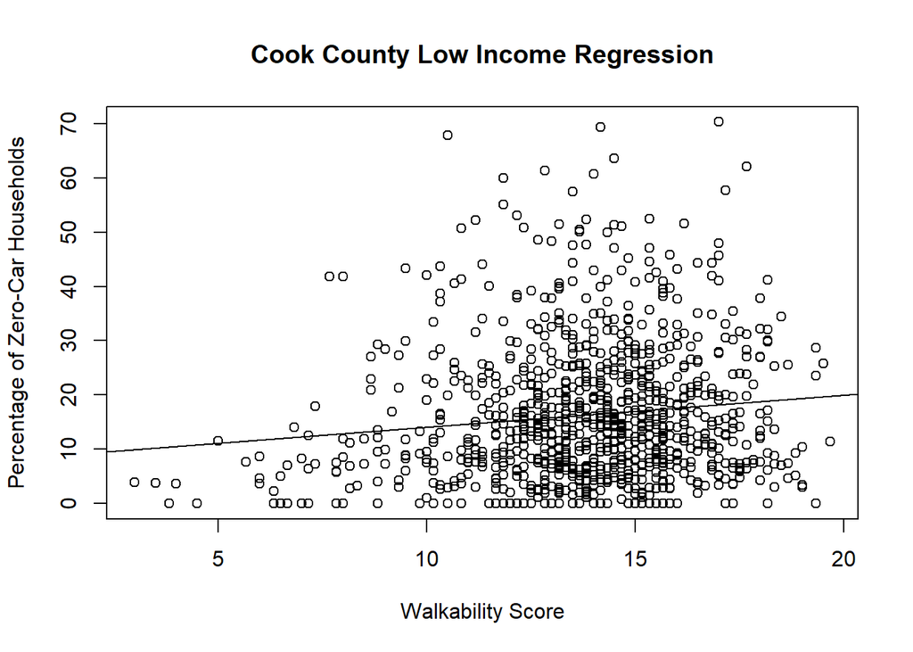

```r
plot(ChicagoLowInc$ZeroCar ~ ChicagoLowInc$NatWalkInd, main="Cook County Low Income Regression", xlab="Walkability Score", ylab="Percentage of Zero-Car Households")
abline(ChicagoLow.reg)
```

```r
ChicagoHighInc <- ChicagoMerged[(ChicagoMerged$MedianIncome >= 150000), ]

ChicagoHigh.reg <- lm(ChicagoHighInc$ZeroCar ~ ChicagoHighInc$NatWalkInd)
summary(ChicagoHigh.reg)
```

```
##
## Call:
## lm(formula = ChicagoHighInc$ZeroCar ~ ChicagoHighInc$NatWalkInd)
##
## Residuals:
##     Min      1Q  Median      3Q     Max
## -12.144  -6.622  -1.740   2.610  25.851
##
## Coefficients:
##                           Estimate Std. Error t value Pr(>|t|)
## (Intercept)                -7.5900     2.4590  -3.087  0.00236 **
## ChicagoHighInc$NatWalkInd   1.0863     0.1732   6.270 2.79e-09 ***
## ---
## Signif. codes:  0 '***' 0.001 '**' 0.01 '*' 0.05 '.' 0.1 ' ' 1
##
## Residual standard error: 8.429 on 173 degrees of freedom
## Multiple R-squared:  0.1852, Adjusted R-squared:  0.1805
## F-statistic: 39.31 on 1 and 173 DF,  p-value: 2.792e-09
```

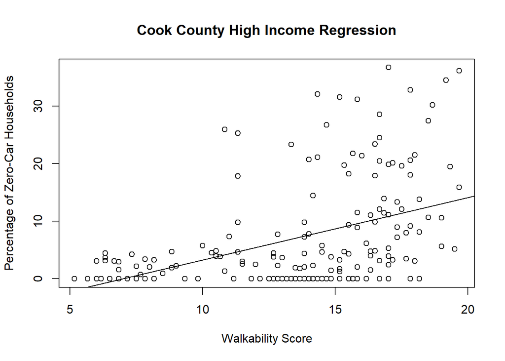

```r
plot(ChicagoHighInc$ZeroCar ~ ChicagoHighInc$NatWalkInd, main="Cook County High Income Regression", xlab="Walkability Score", ylab="Percentage of Zero-Car Households")
abline(ChicagoHigh.reg)
```

The linear regressions in the section above clearly demonstrate a significant positive relationship between a census block group’s score on the National Walkability Index and the number of zero-car households therein at a 95% confidence level. I’m confident that walkable conditions, including pedestrian-friendly infrastructure and a variety of pedestrian-accessible services, do indeed lead residents to forego automobile ownership more often. As such, I reject the null hypothesis that there is no relationship between walkability and automobile ownership. Although two of my regressions had statistically insignificant results, this was certainly due to a lack of data; the regressions performed on Austin and Jacksonville’s high income census block groups had a mere 52 and 5 observations respectively. Every other regression had a P-value for walkability that was far less than 0.05, and only one P-value among them exceeded 0.001.

My regressions have also demonstrated that the positive effect of walkability on zero-car households can be quite strong in addition to being statistically significant. Some of these regressions – particularly Cook County’s high- and middle-income regressions – have slopes implying that walkability can have a predicted overall effect of increasing zero-car households by 20% or more, which supports my prediction that this relationship is stronger in counties where more county-/city-wide public transportation is present.

My suspicion that lower income would correlate with a stronger relationship between walkability and car ownership was also partially supported. In the Travis County and Duval County regressions, there was strong evidence for this prediction. In Duval County, low-income populations had a regression slope of 1.347, while its middle-income regression had a slope of 0.266. Likewise, in Travis County, the low-income regression predicted a slope of 0.92, while the middle-income regression predicted a slope of 0.45. It was only in my regression of Cook County / Chicago that this prediction was not supported. There, the low-income regression had a positive slope that was only about 60% as a steep as the middle- and high-income regressions. I suspect that this may partially be due to somewhat homogeneous walkability conditions among Chicago’s low-income census block groups, meaning a smaller range of observations on which to test a relationship. More testing is required to test the effect of income on this relationship.

### Discussion

Concluding the analysis above, I found that there is a statistically significant positive relationship between walkable census block group conditions (as determined by the National Walkability Index) and the percentage of households therein that own zero automobiles. Likewise, I found that census block groups in counties with more robust intra-city public transportation saw greater decreases in car ownership associated with increases in neighborhood walkability. Additionally, there was limited evidence suggesting that low-income Americans choose to forego automobile ownership more frequently when walkability increases.

In some cases, my analyses in this project exceeded my expectations in regards to the strength of the effect of walkability on automobile ownership. Especially in Travis County and Duval County, which are known to contain fairly unwalkable cities, I expected no more than a 10% increase in predicted zero-car households across its least and most walkable areas, and that was more or less the case in their baseline regressions. However, I think an effect of that magnitude is still impressive in light of the fact that 90% of households in the United States own at least one vehicle. Additionally, I was surprised to see that there was an approximate 20% predicted increase in zero-car households from these counties’ least walkable to most walkable low-income neighborhoods. Likewise, this effect was about the same in magnitude across the majority of Chicago’s census block groups, which was unexpected, but to a lesser degree.

The apparent effect of county-/city-wide infrastructure on this relationship also seemed to be very strong here. While this effect requires more testing to be formally confirmed, the difference in population density and the quality of passenger rail in Austin and Chicago is undeniable; Chicago is considered to have one of the best public transportation systems in the nation and is a more consistently dense city, while Austin has very little in the way of passenger rail and is marked by more sprawl. While it’s clear that walkability has an affect on automobile ownership regardless, it’s also apparent that the same is true of being able to walk in neighborhoods outside of your own. I would like to see more robust analyses on these effects, as well as a wider study on the relationship between income and the rates at which individuals forego automobile ownership.

Finally, I would still like to see this same analysis repeated, but with only those census block groups in the city limits of the respective major cities found in these counties. Unfortunately, I could not find that set of data. Doing so would likely yield more consistent results, as the analysis is otherwise being potentially muddied by census block groups in suburbs where there may be unknown factors affecting our hypothesized relationship.